# Sediment fluxes

Lydia White

2025-05-24

## Set up our environment

### Load libraries

First we load libraries (which you should already have installed).

```r
library(tidyverse)
library(googlesheets4)
library(patchwork)
library(ggpubr)
```

## Import data

```r
gs4_deauth()

# fluxes <- read_sheet("1AyJXPaJZMl1a4vogToBIMSoPDGY2wBq8K3k8g9EptRc", sheet = "sediment_fluxes") #2025

fluxes <- read_sheet("1STH7IQobfCN5dumGnuSGqDiIoqHk1IkAUg3TTRu0pVc", sheet = "sediment_fluxes") #2024
```

## Visualise differences in sediment fluxes

Visualise with boxplots of O2 and ammonium for different sites.

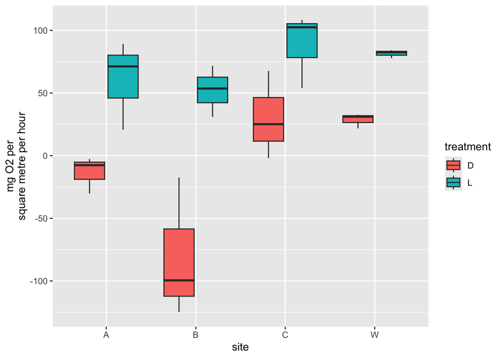

```r
ggplot(fluxes, aes(x=site, y= `O2_flux mg per square metre per hour`, fill = treatment)) +
  geom_boxplot() +
  ylab("mg O2 per\nsquare metre per hour")
```

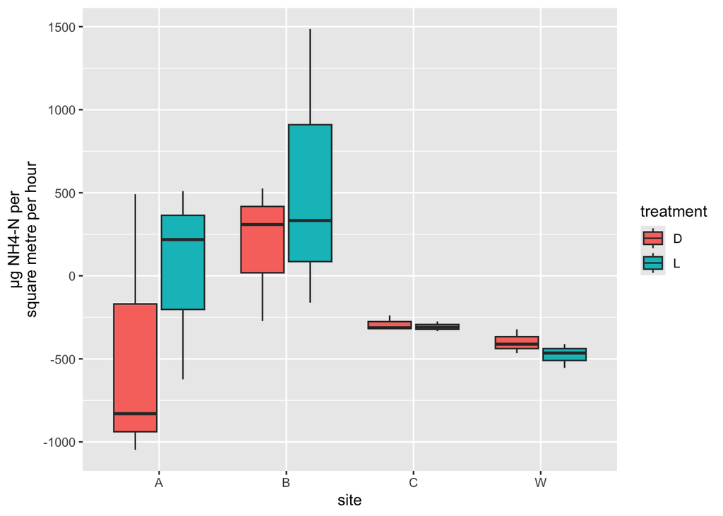

```r
ggplot(fluxes, aes(x=site, y= `NH4_flux µg per square metre per hour`, fill =  treatment)) +
  geom_boxplot() +
  ylab("µg NH4-N per\nsquare metre per hour")
```

You could also test for differences with models (ANOVA, Kruskal-Wallis etc), you could do this separately for light and dark treatments.

```r
light <- fluxes %>% filter (treatment =="L")
dark <- fluxes %>% filter (treatment =="D")

# write script here (copy and paste from previous scripts and change variable names etc)
```

## Are fluxes affected by fauna?

We can explore how fluxes from the sediment are affected by faunal communities via scatter plots. We also need to load in the fauna data, which is per sample.

### Import data

```r
#abundance <- read_sheet("1AyJXPaJZMl1a4vogToBIMSoPDGY2wBq8K3k8g9EptRc" , sheet = "benthos_abundance_per sample")
#2025

abundance <- read_sheet("1STH7IQobfCN5dumGnuSGqDiIoqHk1IkAUg3TTRu0pVc" , sheet = "benthos_abundance_per sample")
#2023

abundance <- abundance %>% select(sample, total_abundance) %>%
  mutate (total_abundance_persqm = total_abundance/0.042^2*pi,)


#biomass <- read_sheet("1AyJXPaJZMl1a4vogToBIMSoPDGY2wBq8K3k8g9EptRc" , sheet = "benthos_biomass_per sample")
#2025

biomass <- read_sheet("1STH7IQobfCN5dumGnuSGqDiIoqHk1IkAUg3TTRu0pVc" , sheet = "benthos_biomass_per sample")
#2023

biomass  <- biomass %>% select(sample, total_biomass_dry) %>%
  mutate (total_biomass_dry_persqm = total_biomass_dry/0.042^2*pi)
```

We can join the flux data and the fauna together as a single dataframe, we join them by their unique sample ID. Lets explore the dark data, i.e. when organisms are respiring.

```r
summary <- inner_join(dark, abundance, by = "sample") %>%
  inner_join(., biomass, by = "sample")
```

### Visualise relationships with scatter plots

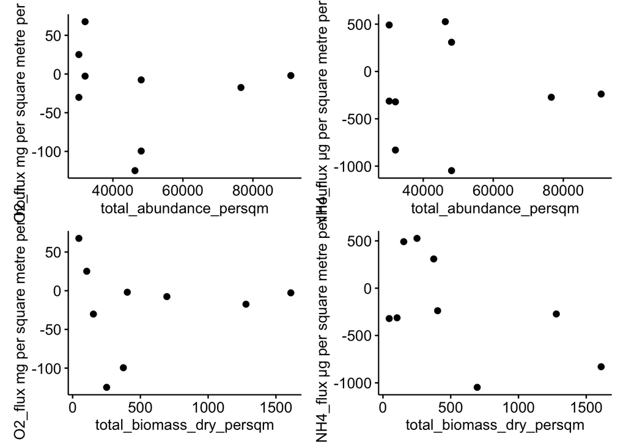

```r
plot_1 <- ggscatter(summary, x = "total_abundance_persqm", y = "O2_flux mg per square metre per hour")
plot_2 <- ggscatter(summary, x = "total_abundance_persqm", y = "NH4_flux µg per square metre per hour")
plot_3 <- ggscatter(summary, x = "total_biomass_dry_persqm", y = "O2_flux mg per square metre per hour")
plot_4 <- ggscatter(summary, x = "total_biomass_dry_persqm", y = "NH4_flux µg per square metre per hour")

(plot_1 + plot_2)/
  (plot_3 + plot_4)
```

### Check assumptions for correlation

Check if data is normal for the 4 variables with shapiro-wilk test, p < 0.05 means data is not normally distributed. If data is normal use pearsons correlation, if its non-normal then use spearmans rank.

```r
shapiro.test(summary$total_abundance_persqm)
```

```
##
##  Shapiro-Wilk normality test
##
## data:  summary$total_abundance_persqm
## W = 0.8087, p-value = 0.02566
```

```r
shapiro.test(summary$total_biomass_dry_persqm)
```

```
##
##  Shapiro-Wilk normality test
##
## data:  summary$total_biomass_dry_persqm
## W = 0.83469, p-value = 0.05039
```

```r
shapiro.test(summary$`O2_flux mg per square metre per hour`)
```

```
##
##  Shapiro-Wilk normality test
##
## data:  summary$`O2_flux mg per square metre per hour`
## W = 0.92563, p-value = 0.4408
```

```r
shapiro.test(summary$`NH4_flux µg per square metre per hour`)
```

```
##
##  Shapiro-Wilk normality test
##
## data:  summary$`NH4_flux µg per square metre per hour`
## W = 0.91632, p-value = 0.3627
```

Some are normal, some might not be, we can replot the data showing correlation coefficents. Adjust which correlation test (spearmans rank or pearsons) you use depending if variables are non-normal or normal.

More information about when to use pearsons or spearmans rank correlation tests can be found here:

https://www.sthda.com/english/wiki/correlation-test-between-two-variables-in-r#google_vignette

Adapt the examples below for your data.

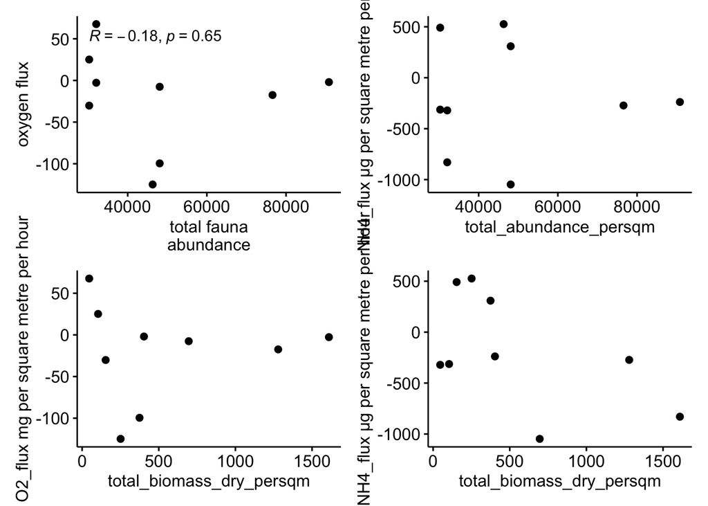

```r
plot_1 <- ggscatter(summary, x = "total_abundance_persqm", y = "O2_flux mg per square metre per hour",
          cor.coef = TRUE, cor.method = "spearman", # not-normal
          xlab = "total fauna\nabundance", ylab = "oxygen flux")


# adapt script above, using the correct correlation test, add script here for plots 2, 3 and 4 and put together in one plot

(plot_1 + plot_2)/
  (plot_3 + plot_4)
```

## Are fluxes affected by organic matter in the sediment?

We can also explore how fluxes from the sediment are affected by the amount of carbon in the sediment via scatter plots. We also need to load in the carbon stocks data.

### Import data

But we only need dark core carbon stock data, as we are comparing against respiration rates, and we don’t need carbon stock data from the deep site you visited with Augusta as we didn’t carry out any incubations there.

```r
# carbon_stocks <- read_sheet("1AyJXPaJZMl1a4vogToBIMSoPDGY2wBq8K3k8g9EptRc", sheet = "carbon_stocks_m2") #2025

carbon_stocks <- read_sheet("1STH7IQobfCN5dumGnuSGqDiIoqHk1IkAUg3TTRu0pVc", sheet = "carbon_stocks_m2") #2023

sed_summary <- inner_join(dark, carbon_stocks, by = c("site", "treatment", "replicate"))
```

### Visualise relationships with scatter plots

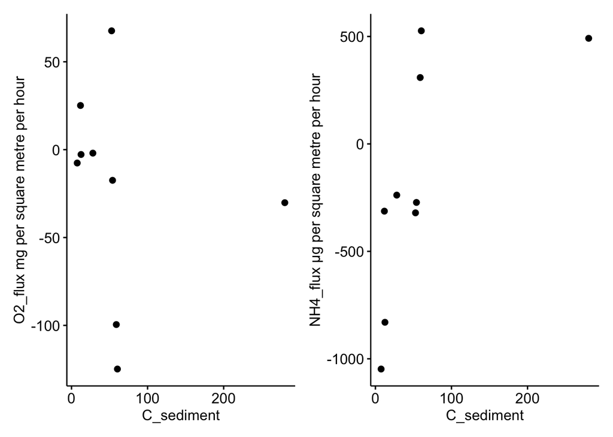

```r
plot_5 <- ggscatter(sed_summary, x = "C_sediment", y = "O2_flux mg per square metre per hour")
plot_6 <- ggscatter(sed_summary, x = "C_sediment", y = "NH4_flux µg per square metre per hour")

plot_5 + plot_6
```

### Check assumptions for correlation

Check if data is normal for the sediment carbon content with shapiro-wilk test, p < 0.05 means data is not normally distributed. If data is normal use pearsons correlation, if its non-normal then use spearmans rank.

```r
shapiro.test(sed_summary$C_sediment)
```

```
##
##  Shapiro-Wilk normality test
##
## data:  sed_summary$C_sediment
## W = 0.62094, p-value = 0.0001685
```

We can replot with correlation coefficients.

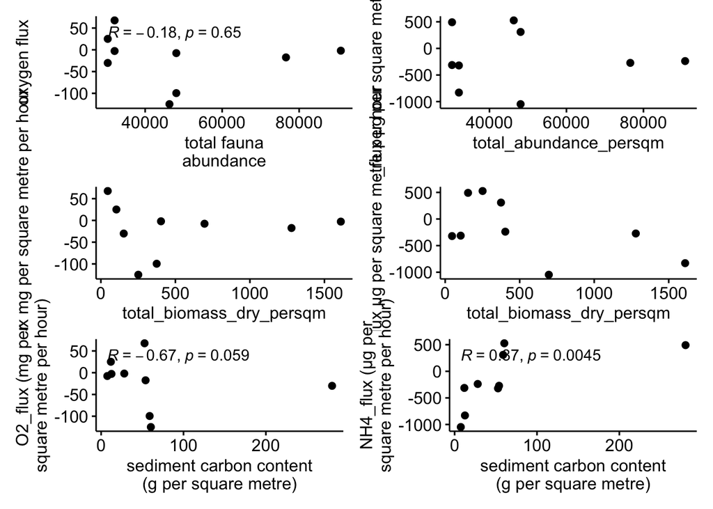

```r
plot_5 <- ggscatter(sed_summary, x = "C_sediment", y = "O2_flux mg per square metre per hour",
          cor.coef = TRUE, cor.method = "spearman",
          xlab = "sediment carbon content\n(g per square metre)", ylab = "O2_flux (mg per\nsquare metre per hour)")

plot_6 <- ggscatter(sed_summary, x = "C_sediment", y = "NH4_flux µg per square metre per hour",
          cor.coef = TRUE, cor.method = "spearman",
          xlab = "sediment carbon content\n(g per square metre)", ylab = "NH4_flux (µg per\nsquare metre per hour)")

(plot_1 + plot_2) /
  (plot_3 + plot_4) /
    (plot_5 + plot_6 )
```

If one of them is significant we can redo figure with added significance line.

Adapt to whichever plot is significant.

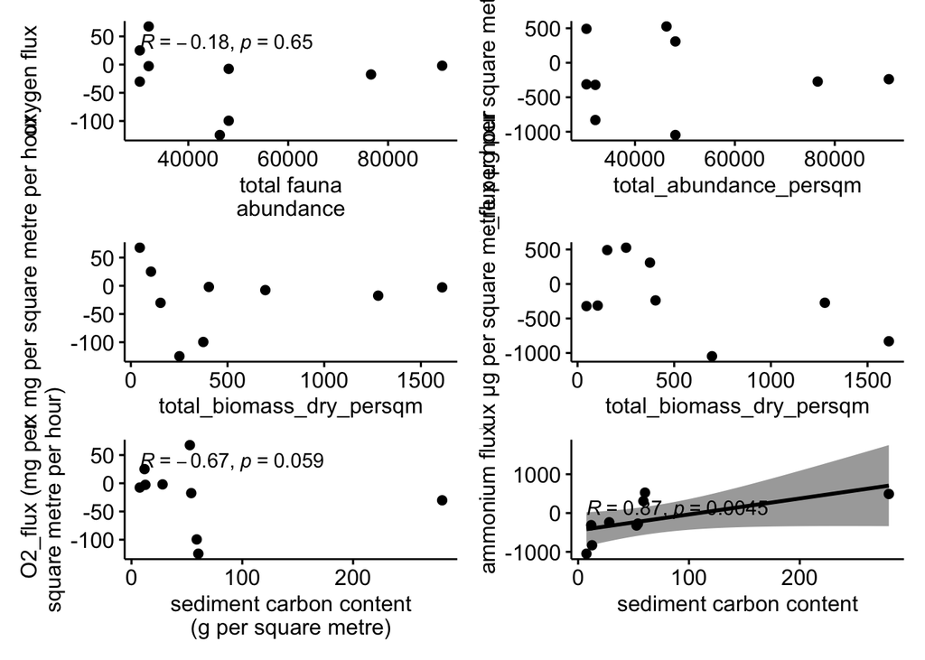

```r
# adapt script to add line for whichever plots have significant variables.

plot_6 <- ggscatter(sed_summary, x = "C_sediment", y = "NH4_flux µg per square metre per hour",
          add = "reg.line", conf.int = TRUE,
          cor.coef = TRUE, cor.method = "spearman",
          xlab = "sediment carbon content", ylab = "ammonium flux")

(plot_1 + plot_2) /
  (plot_3 + plot_4) /
    (plot_5 + plot_6 )
```